# Exam 2 Study

Samuel Kelly

2021-04-09

# Read in data

```r
getwd()
```

```
## [1] "C:/Users/semyu/OneDrive/Desktop/IDE/RPackages/MATH4753Kelly/MATH4753-Applied Statistical Methods/test"
```

```r
shallow <- read.csv("SHALLOW.csv")
head(shallow)
```

```
##   Structure Actual Predict
## 1         1     11      11
## 2         2     11      11
## 3         3     10      12
## 4         4      8       6
## 5         5     11       9
## 6         6      9      10
```

```r
mow <- read.csv("mow-mow.csv")
head(mow)
```

```
##         y1        y2
## 1 10.19633  9.007681
## 2 17.12897 11.301516
## 3 20.23872  8.080292
## 4 18.74534 10.900781
## 5  9.87635  9.397293
## 6 17.87272  8.515708
```

# MoM

$$E(Y^k)=\frac{1}{n}\sum y^k_i$$

# MLE

# 3 Rules of expectation

$$E(c)=c$$

$$E(cY)=cE(Y)$$

$$E(g_1(Y)+...+g_k(Y))=E(g_1(Y))+...+E(g_k(Y))$$

# Rules of Variance

$$V(aX+b)=a^2V(X)$$

# CI

```r
x<-rnorm(40,20,5)
t<-qt(1-.05/2,length(x)-1)
mp<-c(-1,1)
ci <- mean(x)+mp*t*sd(x)/sqrt(length(x))
ci
```

```
## [1] 19.10128 22.25430
```

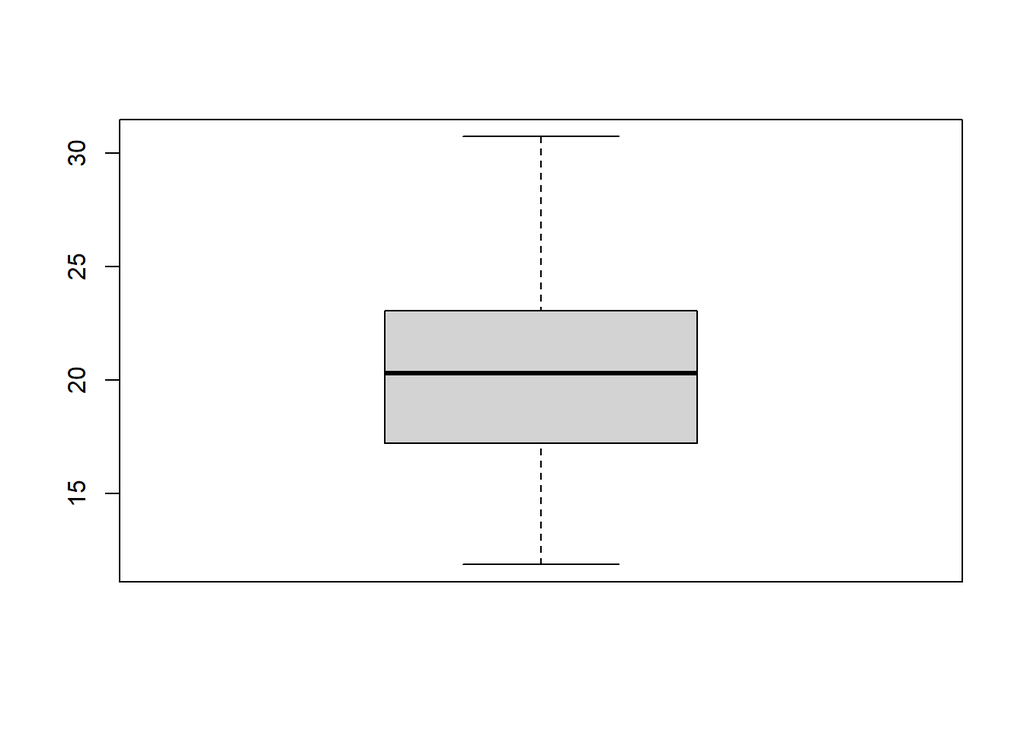

```r
boxplot(x)
```

# t.test

```r
t.test(x,conf.level = .95)$conf.int
```

```
## [1] 19.10128 22.25430
## attr(,"conf.level")
## [1] 0.95
```

```r
y1=rnorm(30,20,5)
y2=rnorm(40,15,8)

t.test(y1,y2,conf.level = .95,var.equal = F) #mu1-mu2, so y1 then y2
```

```
##
##  Welch Two Sample t-test
##
## data:  y1 and y2
## t = 2.2107, df = 67.51, p-value = 0.03045
## alternative hypothesis: true difference in means is not equal to 0
## 95 percent confidence interval:
##  0.3210782 6.2831216
## sample estimates:
## mean of x mean of y
##  20.48360  17.18151
```

```r
t.test(y1,y2,conf.level = .95,var.equal = F)$conf.int #mu1-mu2, so y1 then y2
```

```
## [1] 0.3210782 6.2831216
## attr(,"conf.level")
## [1] 0.95
```

```r
t.test(y2,y1,conf.level = .95,var.equal = F) #mu2-mu1, so y2 then y1
```

```
##
##  Welch Two Sample t-test
##
## data:  y2 and y1
## t = -2.2107, df = 67.51, p-value = 0.03045
## alternative hypothesis: true difference in means is not equal to 0
## 95 percent confidence interval:
##  -6.2831216 -0.3210782
## sample estimates:
## mean of x mean of y
##  17.18151  20.48360
```

# Paired samples

# Use cor()

```r
cor(shallow$Actual,shallow$Predict) # close to one so positively linearly related
```

```
## [1] 0.99593
```

# var.test

```r
var.test(y1,y2)$conf.int
```

```
## [1] 0.3371077 1.3443262
## attr(,"conf.level")
## [1] 0.95
```

```r
# sigma1^2/sigma2^2

t.test(y1,y2,conf.level = .95,var.equal = T)$conf.int #mu1-mu2, so y1 then y2
```

```
## [1] 0.2320993 6.3721005
## attr(,"conf.level")
## [1] 0.95
```

```r
y1=rnorm(30,20,20)
y2=rnorm(40,15,8)
var.test(y1,y2)$conf.int # does not contain 1 in the interval, so variance is not equal
```

```
## [1]  4.171318 16.634483
## attr(,"conf.level")
## [1] 0.95
```

```r
t.test(y1,y2,conf.level = .95,var.equal = F) # plausible the mu1=mu2 since 0 is in conf.int
```

```
##
##  Welch Two Sample t-test
##
## data:  y1 and y2
## t = 1.4434, df = 34.345, p-value = 0.158
## alternative hypothesis: true difference in means is not equal to 0
## 95 percent confidence interval:
##  -2.254988 13.323024
## sample estimates:
## mean of x mean of y
##  19.26404  13.73002
```

# Linear functions

# CLT

# Use CLT

Suppose S = Y_1 + … + Y_n , where Y_i iid Bern(P) Sc ~ N(np, npq) approx, by CLT

Suppose n = 20, p = 0.4 find the following using the Normal approx Hint – YOU MUST draw a normal picture!!!!!

P(S>2), S discrete = approx P(Sc>=2.5) where Sc ~ N cont 1-pnorm(2.5, 20*0.4, sqrt(20*0.4*0.6)) 1-pbinom(2,size =20,prob=0.4)

P( S = 4), S is discrete = approx P( 3.5<=Sc<=4.5) where Sc ~ N cont

pnorm(4.5, 20*0.4, sqrt(20*0.4*0.6)) - pnorm(3.5,20*0.4, sqrt(20*0.4*0.6)) dbinom(4, size =20,prob=0.4)

1-pnorm(2.5, 20*0.4, sqrt(20*0.4*0.6)) 0.9939702 1-pbinom(2,size =20,prob=0.4) 0.9963885 pnorm(4.5, 20*0.4, sqrt(20*0.4*0.6)) - pnorm(3.5,20*0.4, sqrt(20*0.4*0.6)) 0.03508466 dbinom(4, size =20,prob=0.4) 0.03499079

# Quizzes

Suppose that Y∼Weibull(α=2,β=100)

Find P(Y≤8)

In R the parameters for the above would be shape = 2, scale = 10.

```r
pweibull(8,shape = 2,scale = 10)
```

```
## [1] 0.4727076
```

Suppose Y∼Beta(α=2,β=3)

Find the following probability

P(Y>0.3)

In R the parameters for the above problem are shape1 = 2, shape2 = 3.

```r
1-pbeta(.3,shape1 = 2,shape2 = 3)
```

```
## [1] 0.6517
```

Suppose Y∼Exp(β=3)

Find P(Y≤4)

In R the parameter for the above is λ=1/3

```r
pexp(4,rate = 1/3)
```

```
## [1] 0.7364029
```

Suppose Y∼N(10,σ)where the standard deviation σ>0

is unknown.

Find y such that P(Y≤y)=0.5

```r
qnorm(p = .5,mean = 10)
```

```
## [1] 10
```

Please answer the following questions assuming that Y is a continuous random variable. P(3≤Y≤10)=P(3<Y≤10) is TRUE P(Y=10)=? CONTINUOUS at one point is density 0 F(y0)=1−P(Y≤y0) FALSE F(y0)=P(Y≤y0) cumulative distribution function

Suppose that Y∼N(μ=10,σ=4) Find using R P(Y≥11) to 4 decimal places.

```r
1-pnorm(11,mean = 10,sd = 4)
```

```
## [1] 0.4012937
```

Suppose X∼N(μ=10,σ=2) and Y=2X+4

What is the distribution of Y? NORMAL Find the E(Y)
$$E(Y)=E(2X+4)=2E(X)+4=2*10 + 4=24$$
Find the variance of Y – that is find V(Y)
$$V(Y)=V(2X+4)=2^2V(X)=4V(X)=4*2^2=16$$
Suppose that L=Y−5

Find E(L)
$$E(L)=E(Y-5)=E(2X+4)-5=2E(X)+4-5=2*10-1=19$$

Suppose

Yi∼iidN(μ=2,σ=3), and l=1Y1−2Y2+3Y3

Find the numerical value of E(Yi)
$$E(Y_i)=\mu=2$$
Find the numerical value of V(Yi)
$$V(Y_i)=3^2=9$$
Find the numerical value of E(l)
$$E(l)=E(1Y_1-2Y_2+3Y_3)=(1+(-2)+3)E(Y_i)=(2)*2=2*2=4$$
Find the numerical value of V(l)
$$V(l)=V(1Y_1-2Y_2+3Y_3)=1^2V(Y_1)+(-2)^2V(Y_2)+3^2V(Y_3)=V(Y_1)+4V(Y_2)+9V(Y_3)=14*V(Y_i)=14*3^2=14*9=126$$

Suppose that: Yi∼iidN(μ=0,σ=1) L=1Y1−2Y2+3Y3

L takes a Normal distribution TRUE E(L) = 1 FALSE
$$E(L)=E(Y_1)-2E(Y_2)+3E(Y_3)=(1-2+3)E(Y_i)=2*0=0$$
V(L) = 10 FALSE
$$V(L)=(1^2+(-2)^2+3^2)V(Y_i)=14*1^2=14$$
cov(Y1,Y2)=0
$$COV(Y1,Y2)=E(Y1*Y2)-\mu_{Y_{1}}\mu_{Y_2}=0-0=0$$

Suppose that Td∼Bin(n=10,p=0.6)Tc∼N(μ,σ) Where the mean of the binomial is np and the variance is npq. Where Td is the total number of successes in n Bernoulli trials. Tc is the total number of successes on the continuous scale using the CLT.

When using the Normal approximation to the Binomial in the above example what is the numerical value of μ?

```r
10*.6
```

```
## [1] 6
```

What is the numerical value of σ^2 in the Normal approximation to the Binomial

```r
10*.6*.4
```

```
## [1] 2.4
```

Using σ=1.55 and μ=6 Find the Normal approximation to the following probability P(TD>6) to 4 dec places

```r
#P(TD>6)=1-P(TD<=6)=1-P(TD<=6.5)
1-pnorm(6.5,mean = 6,sd = 1.55)
```

```
## [1] 0.3735064
```

Find the exact numerical value of P(T_D>6) to 4 dec. places

```r
1-pbinom(6,size = 10,prob = .6)
```

```
## [1] 0.3822806
```

Suppose that Yi∼iidBern(p) then: T=∑n i=1 Yi Defines a Binomial distribution such that T∼Bin(n,p) TRUE

```r
pnorm(6.5,mean = 5,sd = sqrt(10*.5*.5))
```

```
## [1] 0.8286091
```

If E(θ^)=θ then we would call θ^ an unbiased estimator. TRUE If ρ is the correlation coefficient then 0≤|ρ|≤1 TRUE

Suppose Xi∼iidBin(n=10,p=0.4) Yi∼iidN(μ=10,σ=3) Note that E(Xi)=npV(Xi)=npq And l=2X1+3X2−X3 h=2Y1−3Y2+Y3 V(l)
$$V(l)=(2^2+3^2+(-1)^2)V(X_i)=14*(10*.4*.6)=14*2.4=33.6$$
V(h)
$$V(h)=(2^2+(-3^2)+1^2)V(Y_i)=14*3^2=14*9=126$$
P(3<Yi<7)

```r
pnorm(7,mean = 10,sd = 3)-pnorm(3,mean = 10,sd = 3)
```

```
## [1] 0.1488399
```

P(3<Xi<7)

```r
#P(X_i <= 6) - P(X_i <= 3)
pbinom(6,size = 10,prob = .4)-pbinom(3,size = 10,prob = .4)
```

```
## [1] 0.5629575
```

Suppose the following is true, L=Y1+Y2+Y3+Y4 E(Yi)=3 V(Yi)=4 Yi∼iidD and n=4 To 4 decimal places calculate V(L¯)
$$V(\bar{L})=\frac{V(L)}{n}=\frac{V(Y_1+Y_2+Y_3+Y_4)}{4}=\frac{(1^2+1^2+1^2+1^2)V(Y_i)}{4}=\frac{4*4}{4}=4$$
E(L¯)
$$E(\bar{L})=E(L)=(4)*E(Y_i)=4*3=12$$
V(2L¯)
$$V(2\bar{L})=\frac{2^2V(L)}{n}=\frac{4V(Y_1+Y_2+Y_3+Y_4)}{4}=(1^2+1^2+1^2+1^2)V(Y_i)=4*4=16$$
E(2L¯)
$$E(2\bar{L})=2E(L)=2(4)*E(Y_i)=2*4*3=24$$